# Multiple-view layout

## 0.1 Requirements for this lab

In this lab, you are required to use the skills learned from Module 8 to create a R Markdown which includes multiple-view layout.

#### Please create a R Markdown file, set the output format as html_document or html_document2. Finally knit the R Markdown file into the HTML file.

#### Please use the data provided to conduct a **Multiple-view layout** based on the step mentioned below.

- > Steps:
  > 1. Install and load required packages.
  > 2. Load and inspect the dataset.
  > 3. Plot a grouped histogram for the variable “CrimeRate” based on the groups from the variable using ggplot(). Please note use the colors for scale_color_manual() and scale_fill_manual defined by the code below:

  > > col1=colorspace::diverge_hcl(n)
  > 4. Plot a scatter plot (line+point plot)for the variables “Year” and ” Crimerate”. Please remember to summarize your data after group_by(Year) and then plot the mean crime rate with the Year.For example:

  > > df_new <- df %>% group_by(Year) %>% summarize(mean_rate=mean(CrimeRate),max_rate=max(CrimeRate),min_rate=min(CrimeRate))
  > 5. Plot a grouped box plot for the variable “Crimerate” based on the groups from “Year” from the variable using ggplot(). Please think about if you need to use different colors for different groups here. In the example file, we provide colors for different groups just for the goal of showing how to use colors for grouped boxplots. In this case,you can set one color(grey) or multiple colors for boxplots.
  > 6. Arrange all the three plots in one page using grid.arrange().

#### Please name your file as *Yourname_8.3_Multiple-view layout.RMD*

#### Please knit your R Markdown file into a HTML file and submit the HTML file. Please have the codes and graphs displayed in your file.

## 0.2 Create plots

### A grouped histogram plot

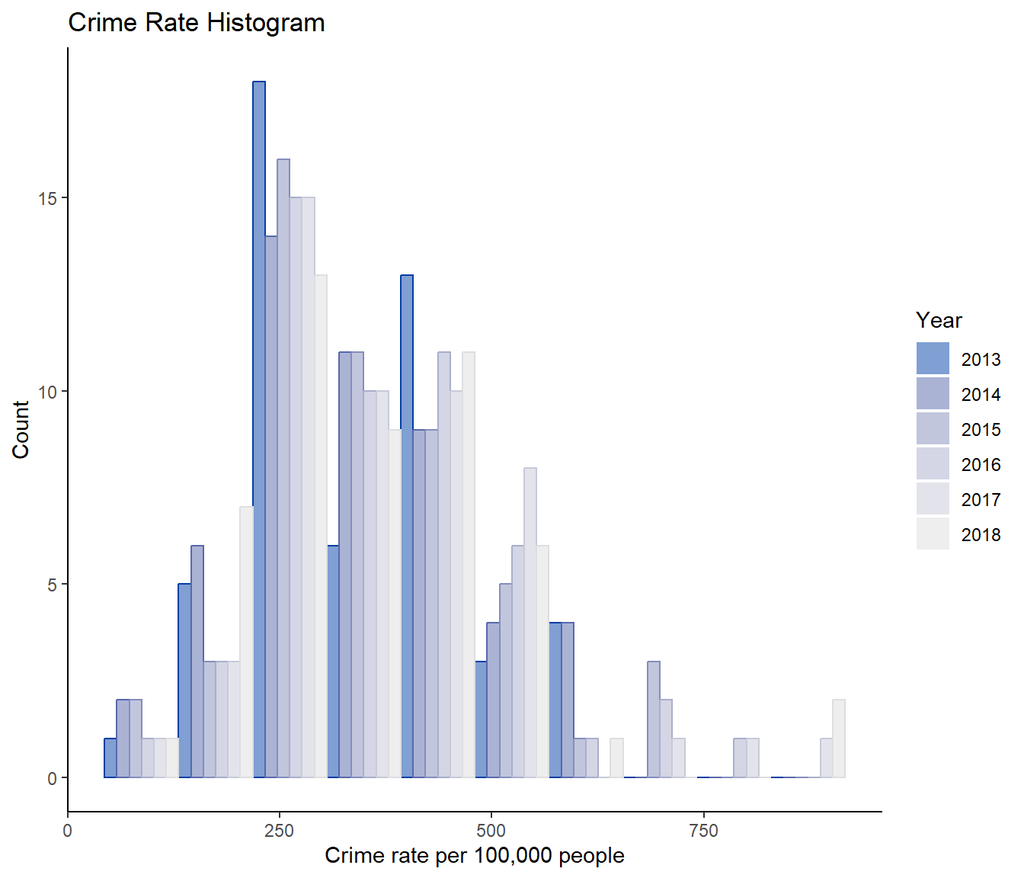

Figure 1: A histogram of Crime Rate over USA

### A scatter plot (A point-line plot)

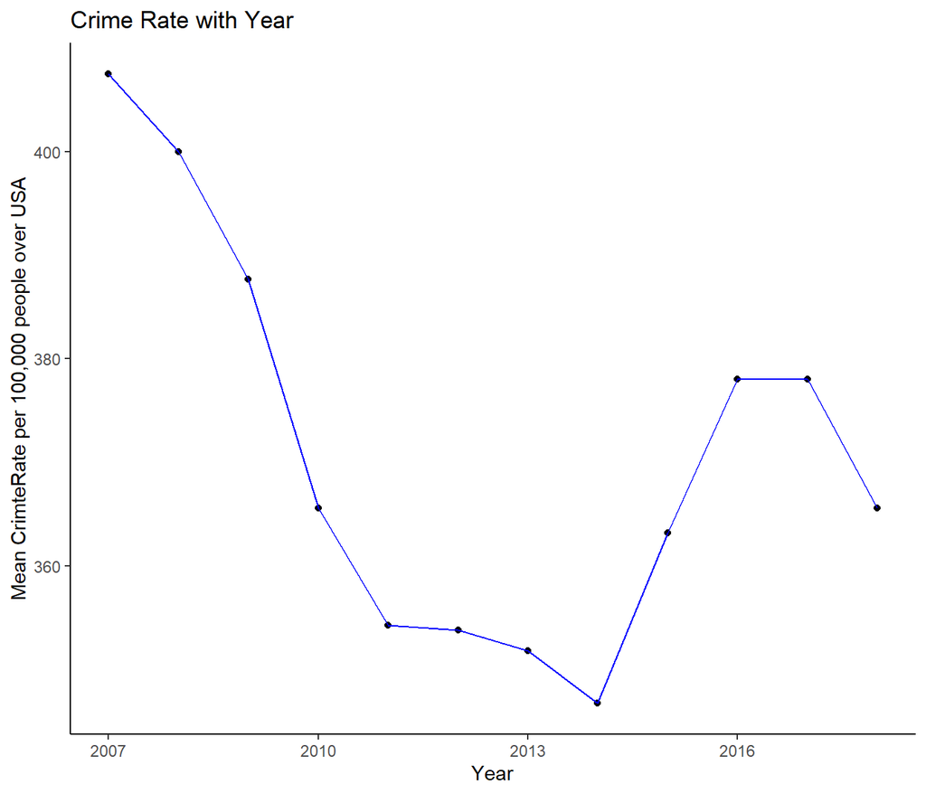

Figure 2: A scatter plot between Crime Rate with Year

### A grouped box plot

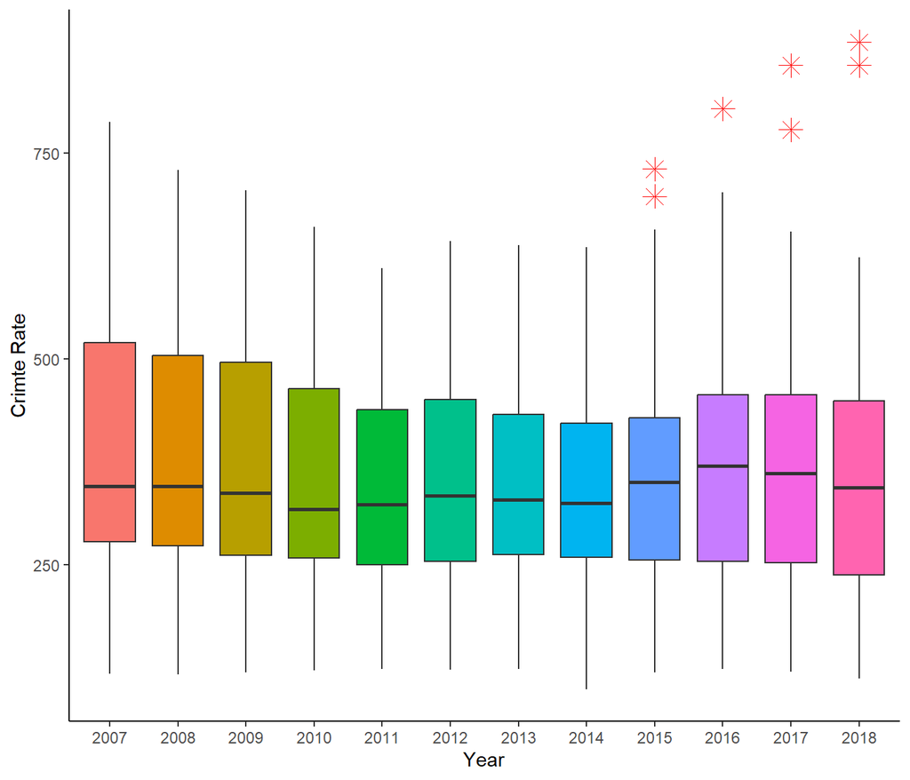

Figure 3: A box plot of Crime Rate

### All three graphs in one plot

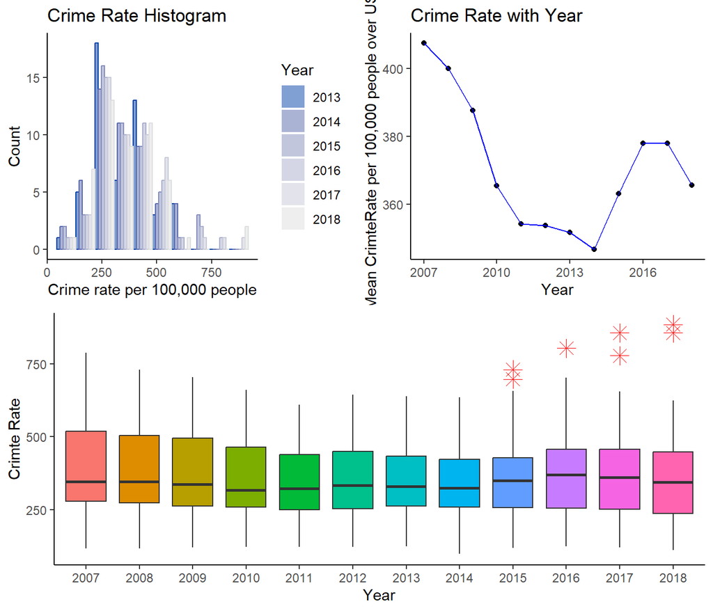

Figure 4: Multiple Plots in one page